This Next-Word-Prediction model predicts 3 choices for the next word based on the text entered in the area provided.

**It uses N-Gram model and deploys below techniques for prediction -**

1. Frequency Matrix was created for 1-Gram to 4-Grams
2. Kenser Ney smoothing with absolute discounting interpolation was deployed for normalizing the probabilities
3. Alternatively, Good Turing smoothing option was also used and is made available as an option
4. Several optimization techniques that utilize the power of R Packages was used

We used 3 data different sources - Blogs, Tweets and News.

**Below is the summary of the source -**

| Sources | SentenceCount | WordCount | Uniquewords | LexicalVariety | WordsperSentence |
| --- | --- | --- | --- | --- | --- |
| Blogs | 899288 | 37334131 | 964437 | 0.0258326 | 41.51521 |
| News | 77259 | 2643969 | 179665 | 0.0679528 | 34.22215 |
| Twitter | 2360148 | 30373543 | 1080322 | 0.0355679 | 12.86934 |

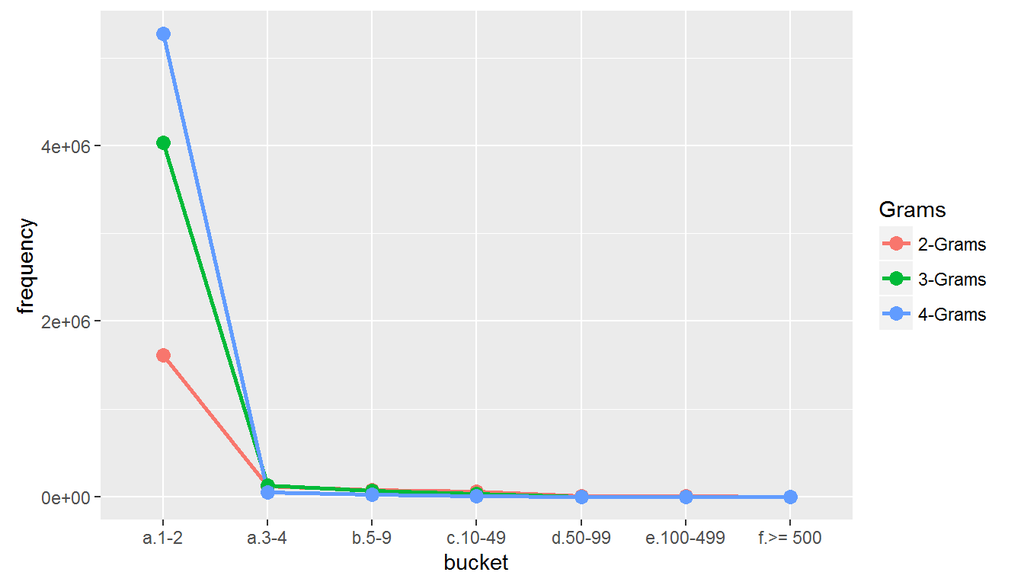